# Methods

# Survey Development and Design

[figure not shown]

Sign on Rainier Vista

The demographics section is meant to gauge the demographics of our sample, and to determine the possible need for weights. We ask about gender, ethnicity, age, year in school, major/intended major, minor, own rating of mental health, experience regarding microaggressions and microcompassions relative to peers, and whether or not they browse UW’s main Facebook meme page: UW Teens for Boundless Memes. This section ends by asking if the survey taker has seen the Resilience Lab signs, and if they answer no, the survey closes as the rest of the questions are not applicable to these people.

The Resilience Lab Signs section is meant to further understand the survey taker’s perceptions of, reactions to, and behavioral change from the signs. Here, we ask about where the people first saw the signs, whether or not they followed the website provided (resilience.uw.edu) on the signs, whether or not their feelings changed and how, how uplifted or discouraged they felt, if their behavior changed and how, if they’ve talked to others about the signs and what they talked about, and finally, how they rate the effectiveness of the signs in terms of promoting microcompassions on campus.

Both sections are important as we used them to draw relationships among different factors within each of the sections (ethnicity versus mental health, rating of mental health versus experience with microaggressions, feelings of being uplifted versus rating of signs’ effectiveness at promoting microcompassions) but also among different factors between the two (major versus rating of signs’ effectiveness at promoting microcompassions, rating of mental health versus feelings of being uplifted).

# Population and Sample Demographics

The population of interest is the UW student community, as they are the main target of the Resilience Lab signs. In terms of keeping our sample representative of the UW student population, we care most about two main demographical dimensions: ethnicity and major. The following table show UW’s ethnicity makeup and our survey takers’ ethnicity makeup.

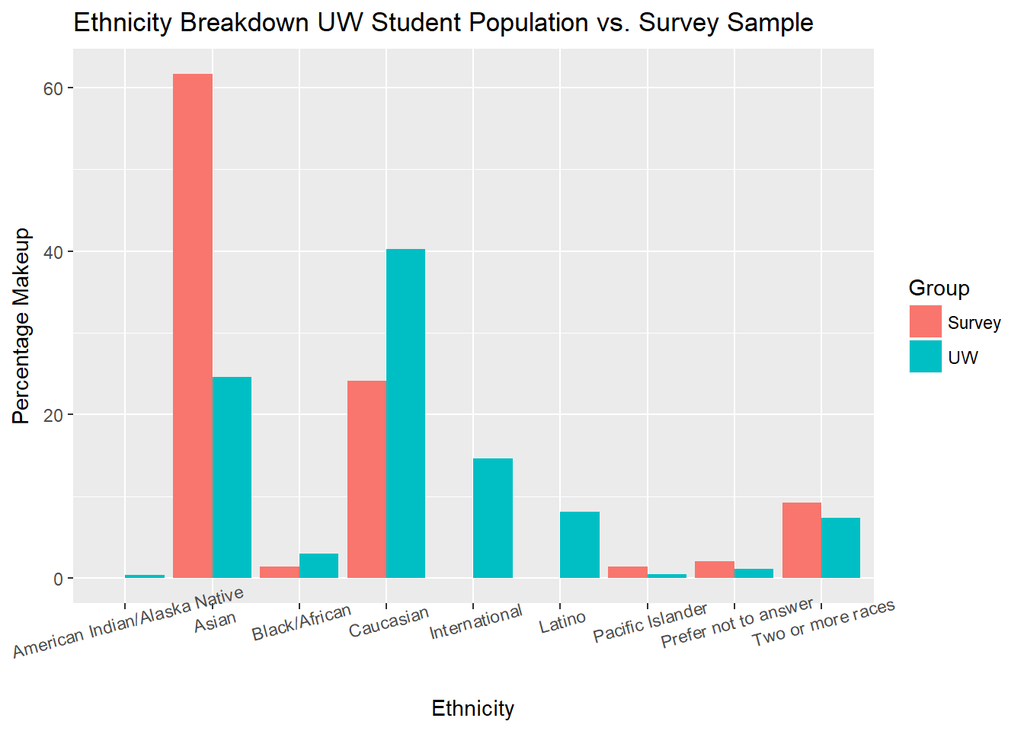

Ethnicity-wise, our survey takers are not very representative of the UW population. For one, our sample consists of ~60% Asians, when the UW population is only ~25% Asian. Caucasians also only make up ~25% of our sample, when they make up ~40% OF THE UW population. Another discrepancy is that Native Americans and Latinos are not represented in our sample. We also have no students in the International category, however that is because we did not include an International option in our survey. Source: [OMAD 2017-2018 Fact Sheet](https://www.washington.edu/omad/files/2017/10/2017-18_OMAD_FACTSHEET_final_10-17-17.pdf)

Top 5 UW Undergrad Majors

| major | count |
| --- | --- |
| Psychology | 944 |
| Computer Science and Engineering | 814 |
| Communication | 760 |
| Biochemistry | 661 |
| Economics | 646 |

Top 5 Survey Sample Majors

| major | count |
| --- | --- |
| Informatics | 36 |
| Electrical Engineering | 12 |
| Business Administration | 10 |
| Public Health | 7 |
| Computer Science & Engineering | 6 |

Major-wise, we have a disproportionate amount of Informatics students and Electrical Engineering students, which makes a lot of sense because we advertised our survey a lot in our INFO 498 class, and also because one of our project members, Elisa, has a lot of Electrical Enginnering friends. Source: [UW Office of the Registrar: Quick Stats](https://studentdata.washington.edu/wp-content/uploads/sites/3/2018/04/Quick_Stats_Seattle_Spr2018.pdf)

# Limitations

Discrepancies and inaccuracy can arise from the misrepresentation of certain demographic groups in our survey. We had considered using survey weights for either ethnicity or major, however decided against it because of the fact that we did not initially stratify our survey. That being said, we are keeping aware of these discrepancies.